# A04_G28512359

JINGSI WU

9/21/2018

## Part A

First, read the dataset file.

```r
mydf <- read.csv("SalesPerformance.csv")
```

Then build a multiple regression model and check the summary of the model

```r
RegMod <- lm(Profit~Area+Popn+Outlets+Commis, data = mydf)
summary(RegMod)
```

```
##
## Call:
## lm(formula = Profit ~ Area + Popn + Outlets + Commis, data = mydf)
##
## Residuals:
##     Min      1Q  Median      3Q     Max
## -773.91  -93.91   25.22  108.02  505.06
##
## Coefficients:
##             Estimate Std. Error t value Pr(>|t|)
## (Intercept) 694.6890   367.1055   1.892  0.06475 .
## Area        -22.9564     8.2917  -2.769  0.00809 **
## Popn        101.7687    61.4965   1.655  0.10476
## Outlets       0.8301     1.5524   0.535  0.59540
## Commis      316.7449    68.4808   4.625 3.05e-05 ***
## ---
## Signif. codes:  0 '***' 0.001 '**' 0.01 '*' 0.05 '.' 0.1 ' ' 1
##
## Residual standard error: 220.6 on 46 degrees of freedom
## Multiple R-squared:  0.6518, Adjusted R-squared:  0.6215
## F-statistic: 21.52 on 4 and 46 DF,  p-value: 4.648e-10
```

```r
mydf_stan <- as.data.frame(scale(mydf))
stanfit <- lm(Profit~Area+Popn+Outlets+Commis, data = mydf_stan)
coef(stanfit)
```

```
##   (Intercept)          Area          Popn       Outlets        Commis
##  8.949929e-17 -4.501429e-01  3.084147e-01  7.074013e-02  4.313395e-01
```

Now build a new model to check whether there is a combination effect of COMMIS and OUTLETS

```r
RegMod2 <- lm(Profit~Area+Popn+Outlets+Commis+Outlets*Commis, data = mydf)
summary(RegMod2)
```

```
##
## Call:
## lm(formula = Profit ~ Area + Popn + Outlets + Commis + Outlets *
##     Commis, data = mydf)
##
## Residuals:
##     Min      1Q  Median      3Q     Max
## -799.69  -95.04   31.13   94.07  543.16
##
## Coefficients:
##                Estimate Std. Error t value Pr(>|t|)
## (Intercept)    1063.492    452.972   2.348   0.0233 *
## Area            -20.871      8.355  -2.498   0.0162 *
## Popn            121.381     62.595   1.939   0.0588 .
## Outlets          -1.719      2.418  -0.711   0.4809
## Commis         -275.839    439.123  -0.628   0.5331
## Outlets:Commis    3.303      2.418   1.366   0.1788
## ---
## Signif. codes:  0 '***' 0.001 '**' 0.01 '*' 0.05 '.' 0.1 ' ' 1
##
## Residual standard error: 218.6 on 45 degrees of freedom
## Multiple R-squared:  0.6656, Adjusted R-squared:  0.6285
## F-statistic: 17.92 on 5 and 45 DF,  p-value: 9.639e-10
```

From the second model we can see that by adding a new variable OUTLETS*COMMIS, the p-value of this variable does not reach the significant level we set (95%), so there is no cobination effect between this two variables.

Now let’s check whether we should use PROFIT or PROFIT divided by OUTLETS as the dependent variable.

```r
RegMod3 <- lm(Profit/Outlets~ Area + Popn + Commis, data = mydf)
summary(RegMod3)
```

```
##
## Call:
## lm(formula = Profit/Outlets ~ Area + Popn + Commis, data = mydf)
##
## Residuals:
##     Min      1Q  Median      3Q     Max
## -4.9040 -0.6038  0.0779  0.8308  2.4466
##
## Coefficients:
##             Estimate Std. Error t value Pr(>|t|)
## (Intercept)   7.0652     1.8471   3.825 0.000384 ***
## Area         -0.1536     0.0480  -3.200 0.002462 **
## Popn          0.0258     0.3196   0.081 0.935995
## Commis        2.0420     0.3912   5.220 3.98e-06 ***
## ---
## Signif. codes:  0 '***' 0.001 '**' 0.01 '*' 0.05 '.' 0.1 ' ' 1
##
## Residual standard error: 1.281 on 47 degrees of freedom
## Multiple R-squared:  0.5527, Adjusted R-squared:  0.5242
## F-statistic: 19.36 on 3 and 47 DF,  p-value: 2.58e-08
```

The Adjusted R-squared become smaller, it is not a good model, so we’ll keep use PROFIT as the dependent variable.

## Part B

To omit the variables, we use strpwise method.

```r
step <- stepAIC(RegMod, direction = "both")
```

```
## Start:  AIC=555.17
## Profit ~ Area + Popn + Outlets + Commis
##
##           Df Sum of Sq     RSS    AIC
## - Outlets  1     13917 2252655 553.49
## <none>                 2238739 555.17
## - Popn     1    133283 2372022 556.12
## - Area     1    373045 2611784 561.03
## - Commis   1   1041184 3279923 572.65
##
## Step:  AIC=553.49
## Profit ~ Area + Popn + Commis
##
##           Df Sum of Sq     RSS    AIC
## <none>                 2252655 553.49
## + Outlets  1     13917 2238739 555.17
## - Popn     1    217890 2470545 556.19
## - Area     1    386658 2639314 559.56
## - Commis   1   1031720 3284375 570.72
```

After stepwise, OUTLETS has been removed from the model, since POPN also don’t reach our significant level, and by removing it the AIC will not increase a lot, so we’ll also omit POPN. Now let’s see build a new model with this result and summarize it.

```r
RegMod4 <- lm(Profit~Area+Commis, data = mydf)
summary(RegMod4)
```

```
##
## Call:
## lm(formula = Profit ~ Area + Commis, data = mydf)
##
## Residuals:
##     Min      1Q  Median      3Q     Max
## -783.95 -117.63   -2.08  110.97  624.18
##
## Coefficients:
##             Estimate Std. Error t value Pr(>|t|)
## (Intercept) 1447.604     75.378  19.205  < 2e-16 ***
## Area         -38.003      4.605  -8.252 9.19e-11 ***
## Commis       268.936     66.315   4.055 0.000183 ***
## ---
## Signif. codes:  0 '***' 0.001 '**' 0.01 '*' 0.05 '.' 0.1 ' ' 1
##
## Residual standard error: 226.9 on 48 degrees of freedom
## Multiple R-squared:  0.6157, Adjusted R-squared:  0.5997
## F-statistic: 38.45 on 2 and 48 DF,  p-value: 1.077e-10
```

Now the model looks better, altough the adjusted R-squared decrease a tiny little bit, but the significant level of the rest variables have increased. Also, the p-value of F-statistic become smaller.

For more imformation to get a precise model, we can plot it and see the pictures.

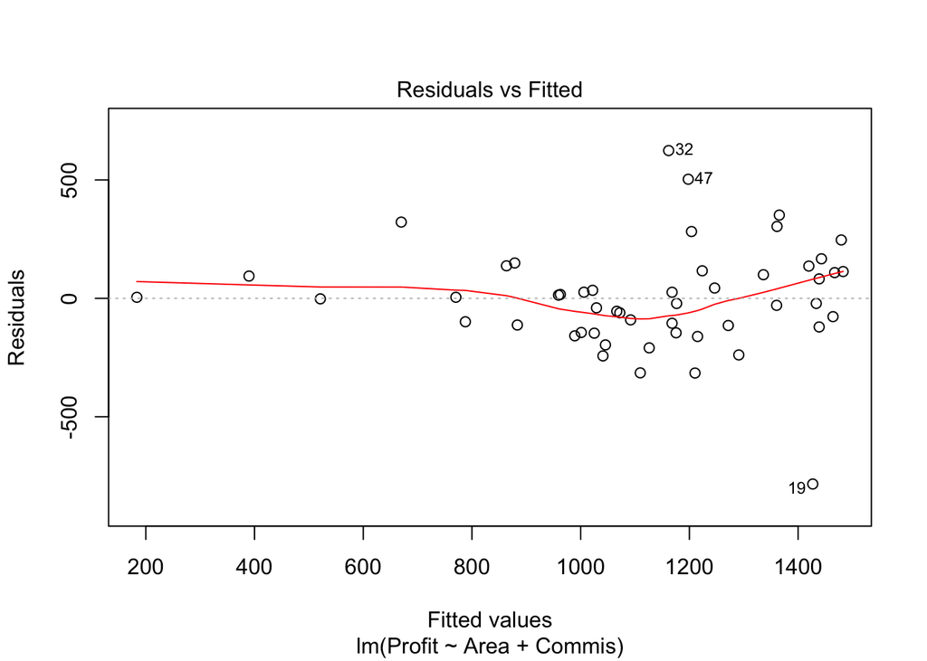

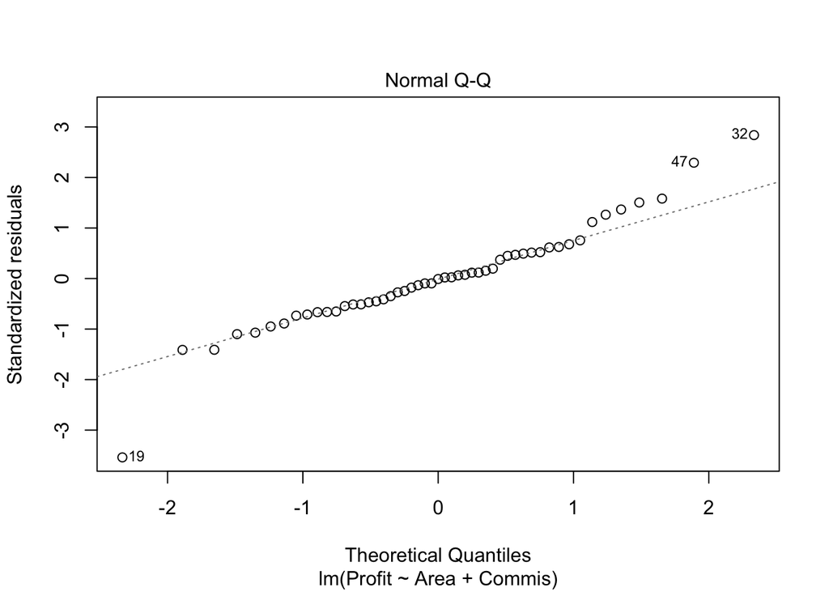

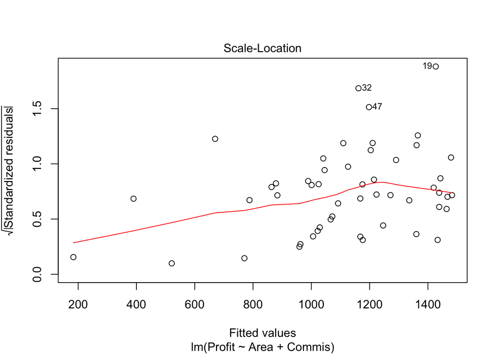

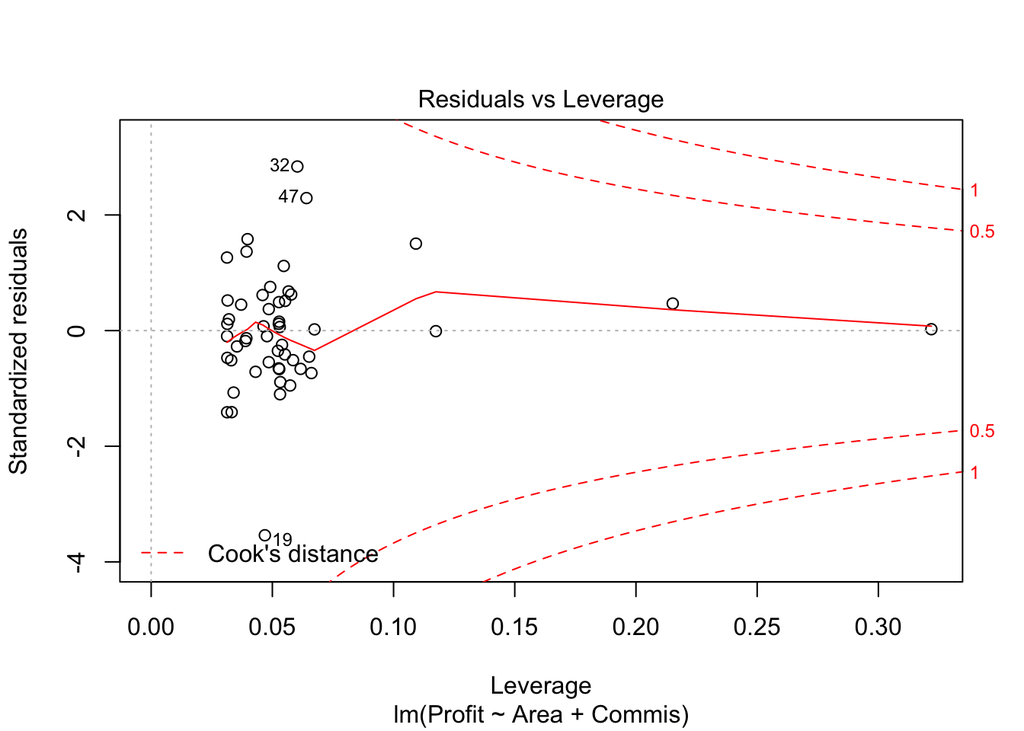

```r
plot(RegMod4)
```

```r
mydf <- mydf[-(27), -(47)]
RegMod4 <- lm(Profit~Area+Commis, data = mydf)
summary(RegMod4)
```

```
##
## Call:
## lm(formula = Profit ~ Area + Commis, data = mydf)
##
## Residuals:
##     Min      1Q  Median      3Q     Max
## -794.51 -124.16   -2.65  101.43  623.91
##
## Coefficients:
##             Estimate Std. Error t value Pr(>|t|)
## (Intercept) 1448.341     74.578  19.421  < 2e-16 ***
## Area         -38.066      4.557  -8.354 7.59e-11 ***
## Commis       279.230     66.005   4.230 0.000107 ***
## ---
## Signif. codes:  0 '***' 0.001 '**' 0.01 '*' 0.05 '.' 0.1 ' ' 1
##
## Residual standard error: 224.5 on 47 degrees of freedom
## Multiple R-squared:  0.6287, Adjusted R-squared:  0.6129
## F-statistic: 39.79 on 2 and 47 DF,  p-value: 7.747e-11
```

```r
vif(RegMod4)
```

```
##     Area   Commis
## 1.018658 1.018658
```

## Part C

From the result above we can see that when the district area become larger, the profit of representative will decrease, because they have to spend more time on travlling. Also other factors do have effect on the profit, but their effect are not as much as AREA and COMMIS.

In the model, we discover that OUTLETS and COMMIS don’t have any combination effect, they are two independent variables to the PROFIT.

Useing PROFIT devided by OUTLETS as dependent variable is not a good choice, it will decrease the accuracy of the model.

## Part D

2.Also, we detect that there is no relationship between OUTLETS and COMMIS, they will not affect each other.

4.Some data in the dataset are not reasonable, in order to increase the accruacy, we delete some of the data and gain the final model. This model can be used to predict the performance of each representatives and help them to improve it.